# Visual patterns test analysis

# The study

### Familiarization phase

Participants see 5 stimuli repeated 8 times each. Stimuli consist of a 3x3 grid, with 5 random shapes (circle,triangle,square) placed randomly (any 9 cells) with random color (red,blue,yellow,green,orange,purple).

### Study phase

Participants see the 5 familiar stimuli 5 times each (25) and 50 novel stimuli. They have to judge if the current stimulus is one of the familiars. The novels differ to a differing degree from the familiars: there is 5x2 (two for each familiar) that is wholly different (diffarr). 5x2 that has the same placement of random shapes (sarr), 5x2 same arrangement and shapes (sarrsha), 5x2 same arrangement and colors (sarrcol) 5x2 same arrangement, shapes and colors (colors are randomized, thus, these are not the same as the familiars - sarrshacol).

### Test phase

Participants see the novels from the study phase and 50 new stimuli (sarr - 10, sarrsha - 10, etc.). Participants have to signal if they have already seen the current stimulus or it is wholly new. They had the option to signal “maybe”, but were asked to do this in moderation (maybe resp <= 20). These responses have been added to correct responses.

## Participants

The online task has been started by a total of 69 participants.

We excluded a total of 9 participants due to irregular data (incomplete runs, several runs).

We also excluded some (1) participants as they missed more than 66.3065823 trials (mean + 2*sd of misses by participant).

We also excluded those who recognized less than half of the prototypes in the study phase (14). [inactive - this would drop 14 participants]

We also excluded 5 participants as they overused “maybe” responses in the test phase (more than 25).

Maybe responses [mean(±sd)] : 10.1463415 ± 7.0588986

The sample had a mean(±sd) age of 23.025641 ± 4.8530358.

The histogram below shows the number of participants completing the task in a given hour of the day.

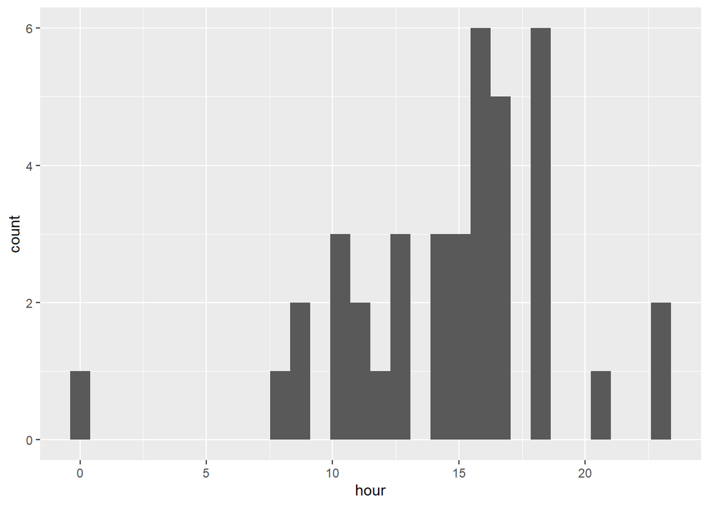

## Study phase:

During the study phase, the participants see familiar and novel items.

The original sample of 41 participants produced a mean (±sd) recognition rate of 0.7121951 ± 0.1012796 for familiar pictures.

The sample performed above chance levels, as a one sample t-test showed (t(40)=13.4154508, p = 2.154104610^{-16}, Cohen’s d = 2.0951414, 95% CI:1.3095359 - 2.880747).

We use an ANOVA to see if there is a difference in correct rejection for the different novels.

```
## Anova Table (Type 3 tests)
##
## Response: crrate
##   Effect           df  MSE         F  ges p.value
## 1   type 3.52, 140.77 0.02 16.07 *** .125   <.001
## ---
## Signif. codes:  0 '***' 0.001 '**' 0.01 '*' 0.05 '+' 0.1 ' ' 1
##
## Sphericity correction method: GG
```

```
##  contrast             estimate     SE  df t.ratio p.value
##  diffarr - sarr        0.13171 0.0288 160  4.569  0.0001
##  diffarr - sarrcol     0.12439 0.0288 160  4.316  0.0003
##  diffarr - sarrsha     0.22927 0.0288 160  7.954  <.0001
##  diffarr - sarrshacol  0.10488 0.0288 160  3.639  0.0034
##  sarr - sarrcol       -0.00732 0.0288 160 -0.254  0.9991
##  sarr - sarrsha        0.09756 0.0288 160  3.385  0.0079
##  sarr - sarrshacol    -0.02683 0.0288 160 -0.931  0.8846
##  sarrcol - sarrsha     0.10488 0.0288 160  3.639  0.0034
##  sarrcol - sarrshacol -0.01951 0.0288 160 -0.677  0.9612
##  sarrsha - sarrshacol -0.12439 0.0288 160 -4.316  0.0003
##
## P value adjustment: tukey method for comparing a family of 5 estimates
```

```
##  contrast  estimate     SE  df t.ratio p.value
##  linear     -0.3073 0.0645 160 -4.768  <.0001
##  quadratic   0.4000 0.0763 160  5.245  <.0001
##  cubic       0.0902 0.0645 160  1.400  0.1634
##  quartic     0.5927 0.1705 160  3.476  0.0007
```

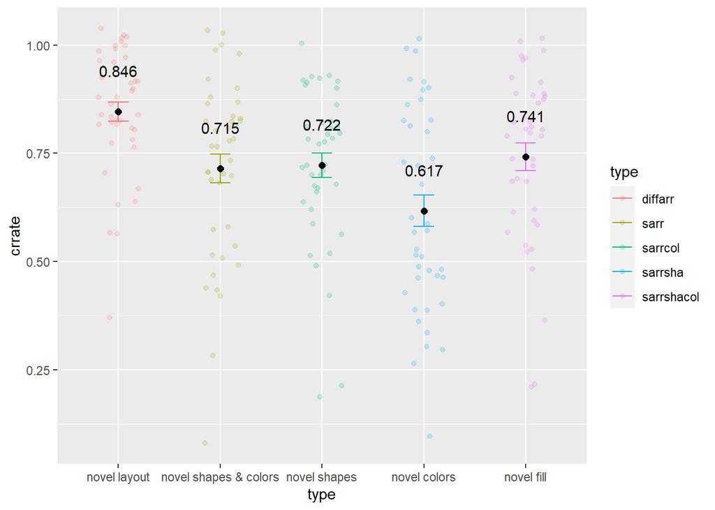

## Test phase:

```
## [1] "A t-test to compare the number of old responses btwn old and new stim"
```

```
##
##  Paired t-test
##
## data:  a and b
## t = 1.908, df = 44, p-value = 0.06293
## alternative hypothesis: true difference in means is not equal to 0
## 95 percent confidence interval:
##  -0.06000358  2.19333691
## sample estimates:
## mean of the differences
##                1.066667
```

```
##
## Cohen's d
##
## d estimate: 0.1349974 (negligible)
## 95 percent confidence interval:
##        lower        upper
## -0.006246653  0.276241431
```

```
##
##  Shapiro-Wilk normality test
##
## data:  d
## W = 0.97579, p-value = 0.4603
```

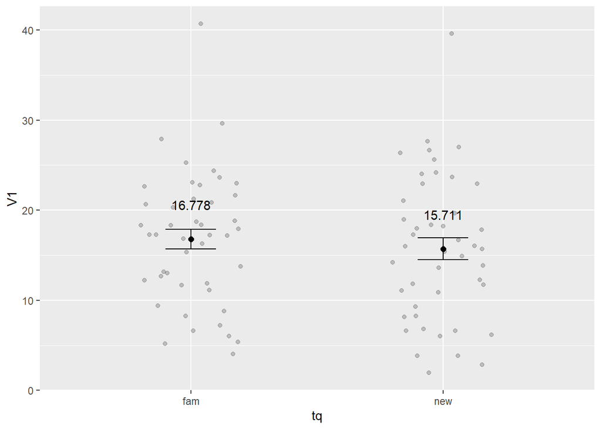

```
## [1] "ANOVA with correct recognition minus false alarm by category"
```

```
## Anova Table (Type 3 tests)
##
## Response: CorrectedRecognitions
##   Effect           df  MSE        F  ges p.value
## 1   type 3.56, 142.40 4.28 6.67 *** .106   <.001
## ---
## Signif. codes:  0 '***' 0.001 '**' 0.01 '*' 0.05 '+' 0.1 ' ' 1
##
## Sphericity correction method: GG
```

```
##  contrast             estimate    SE  df t.ratio p.value
##  diffarr - sarr          0.390 0.431 160  0.905  0.8946
##  diffarr - sarrcol       1.415 0.431 160  3.281  0.0110
##  diffarr - sarrsha       0.171 0.431 160  0.396  0.9948
##  diffarr - sarrshacol    1.756 0.431 160  4.073  0.0007
##  sarr - sarrcol          1.024 0.431 160  2.376  0.1274
##  sarr - sarrsha         -0.220 0.431 160 -0.509  0.9864
##  sarr - sarrshacol       1.366 0.431 160  3.168  0.0156
##  sarrcol - sarrsha      -1.244 0.431 160 -2.885  0.0356
##  sarrcol - sarrshacol    0.341 0.431 160  0.792  0.9327
##  sarrsha - sarrshacol    1.585 0.431 160  3.677  0.0029
##
## P value adjustment: tukey method for comparing a family of 5 estimates
```

```
##  contrast  estimate    SE  df t.ratio p.value
##  linear      -3.293 0.964 160 -3.415  0.0008
##  quadratic   -0.122 1.141 160 -0.107  0.9150
##  cubic       -2.195 0.964 160 -2.277  0.0241
##  quartic     -8.000 2.551 160 -3.136  0.0020
```

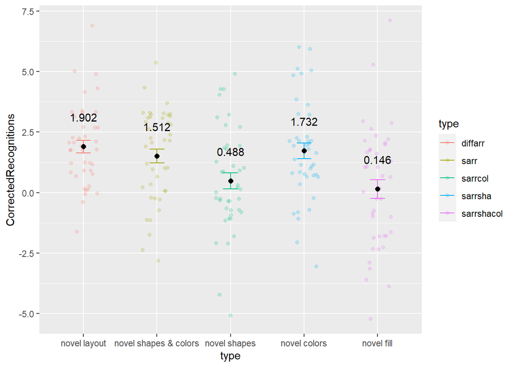

```
## [1] "ANOVA with correct rejection minus false alarm by category"
```

```
## Anova Table (Type 3 tests)
##
## Response: CorrectedRejections
##   Effect           df  MSE       F  ges p.value
## 1   type 3.44, 137.41 4.46 4.13 ** .073    .005
## ---
## Signif. codes:  0 '***' 0.001 '**' 0.01 '*' 0.05 '+' 0.1 ' ' 1
##
## Sphericity correction method: GG
```

```
##  contrast             estimate    SE  df t.ratio p.value
##  diffarr - sarr         0.4878 0.432 160  1.128  0.7914
##  diffarr - sarrcol      1.4390 0.432 160  3.328  0.0094
##  diffarr - sarrsha      0.6585 0.432 160  1.523  0.5490
##  diffarr - sarrshacol   1.4146 0.432 160  3.272  0.0113
##  sarr - sarrcol         0.9512 0.432 160  2.200  0.1850
##  sarr - sarrsha         0.1707 0.432 160  0.395  0.9948
##  sarr - sarrshacol      0.9268 0.432 160  2.144  0.2070
##  sarrcol - sarrsha     -0.7805 0.432 160 -1.805  0.3742
##  sarrcol - sarrshacol  -0.0244 0.432 160 -0.056  1.0000
##  sarrsha - sarrshacol   0.7561 0.432 160  1.749  0.4073
##
## P value adjustment: tukey method for comparing a family of 5 estimates
```

```
##  contrast  estimate    SE  df t.ratio p.value
##  linear       -3.00 0.967 160 -3.103  0.0023
##  quadratic     1.20 1.144 160  1.045  0.2977
##  cubic        -1.07 0.967 160 -1.110  0.2686
##  quartic      -5.46 2.558 160 -2.136  0.0342
```

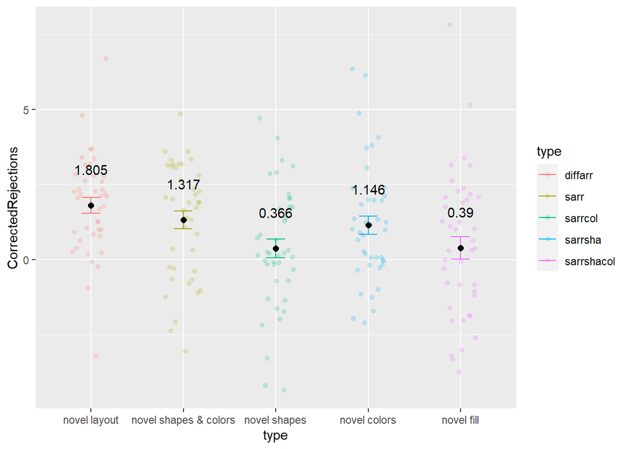

```
## [1] "ANOVA with corrected differentiation score by category ((crecog-fa)+(creject-fa))"
```

```
## Anova Table (Type 3 tests)
##
## Response: OCCategorizations
##   Effect           df   MSE        F  ges p.value
## 1   type 3.48, 139.26 16.53 5.48 *** .091   <.001
## ---
## Signif. codes:  0 '***' 0.001 '**' 0.01 '*' 0.05 '+' 0.1 ' ' 1
##
## Sphericity correction method: GG
```

```
##  contrast             estimate    SE  df t.ratio p.value
##  diffarr - sarr         0.8780 0.838 160  1.048  0.8325
##  diffarr - sarrcol      2.8537 0.838 160  3.406  0.0073
##  diffarr - sarrsha      0.8293 0.838 160  0.990  0.8596
##  diffarr - sarrshacol   3.1707 0.838 160  3.785  0.0020
##  sarr - sarrcol         1.9756 0.838 160  2.358  0.1324
##  sarr - sarrsha        -0.0488 0.838 160 -0.058  1.0000
##  sarr - sarrshacol      2.2927 0.838 160  2.737  0.0531
##  sarrcol - sarrsha     -2.0244 0.838 160 -2.416  0.1162
##  sarrcol - sarrshacol   0.3171 0.838 160  0.378  0.9956
##  sarrsha - sarrshacol   2.3415 0.838 160  2.795  0.0455
##
## P value adjustment: tukey method for comparing a family of 5 estimates
```

```
##  contrast  estimate   SE  df t.ratio p.value
##  linear       -6.29 1.87 160 -3.359  0.0010
##  quadratic     1.07 2.22 160  0.484  0.6289
##  cubic        -3.27 1.87 160 -1.745  0.0830
##  quartic     -13.46 4.96 160 -2.716  0.0073
```

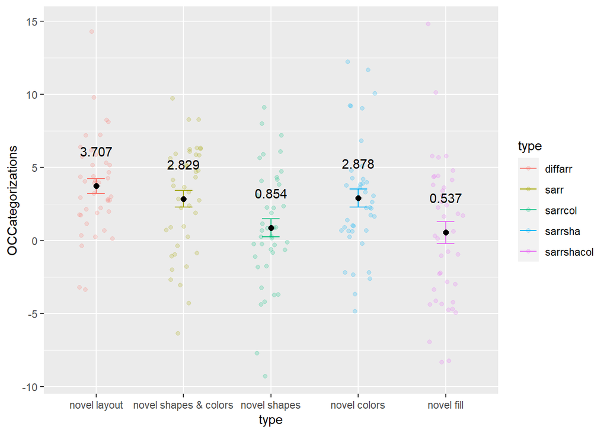

# Mixed models

## The metrics

### DTF - Difference To corresponding Familiar picture

All pictures are compared to a familiar. The number of differences between the three vectors of the pictures yields a difference score.

### DTAF - mean Difference To All Familiars

We calculate the difference from all prototypes and take the mean for each picture in the set.

### DTAN - mean Difference To All other Novels in the same category

We calculate the differences between each pair of pictures and then take the mean of these differences (19 comparisons per stim).

### DTN_byPhase - mean Difference to Novels in the same category per study/test phase

We calculate the differences between each pair of pictures and then take the mean of these differences (9 comparisons per stim).

### DTPPm - mean Diff To Previously seen Pictures

We compare the current picture to all previously seen pictures (25 in first study trial, 26 in 2nd, and so on ..). We take the mean.

## Study phase

```
## Generalized linear mixed model fit by maximum likelihood (Laplace
##   Approximation) [glmerMod]
##  Family: binomial  ( logit )
## Formula: st_corr ~ factor(type) + (1 | workerId)
##    Data: stlmm
##
##      AIC      BIC   logLik deviance df.resid
##   3489.3   3531.5  -1737.6   3475.3     3068
##
## Scaled residuals:
##     Min      1Q  Median      3Q     Max
## -3.0884 -1.0430  0.4995  0.6362  1.5349
##
## Random effects:
##  Groups   Name        Variance Std.Dev.
##  workerId (Intercept) 0.2942   0.5424
## Number of obs: 3075, groups:  workerId, 41
##
## Fixed effects:
##                        Estimate Std. Error z value Pr(>|z|)
## (Intercept)              1.8038     0.1638  11.015  < 2e-16 ***
## factor(type)prototype   -0.8394     0.1563  -5.371 7.83e-08 ***
## factor(type)sarr        -0.8268     0.1789  -4.622 3.80e-06 ***
## factor(type)sarrcol     -0.7886     0.1794  -4.395 1.11e-05 ***
## factor(type)sarrsha     -1.2948     0.1745  -7.420 1.17e-13 ***
## factor(type)sarrshacol  -0.6836     0.1810  -3.777 0.000159 ***
## ---
## Signif. codes:  0 '***' 0.001 '**' 0.01 '*' 0.05 '.' 0.1 ' ' 1
##
## Correlation of Fixed Effects:
##                 (Intr) fctr(typ)p factr(typ)srr fctr(typ)srrc factr(typ)srrsh
## fctr(typ)pr     -0.761
## factr(typ)srr   -0.665  0.694
## fctr(typ)srrc   -0.663  0.692      0.605
## factr(typ)srrsh -0.684  0.713      0.623         0.621
## fctr(typ)srrshc -0.656  0.686      0.599         0.598         0.615
```

```
## Package `effects` is not available, but needed for `ggeffect()`. Either install package `effects`, or use `ggpredict()`. Calling `ggpredict()` now.FALSE
```

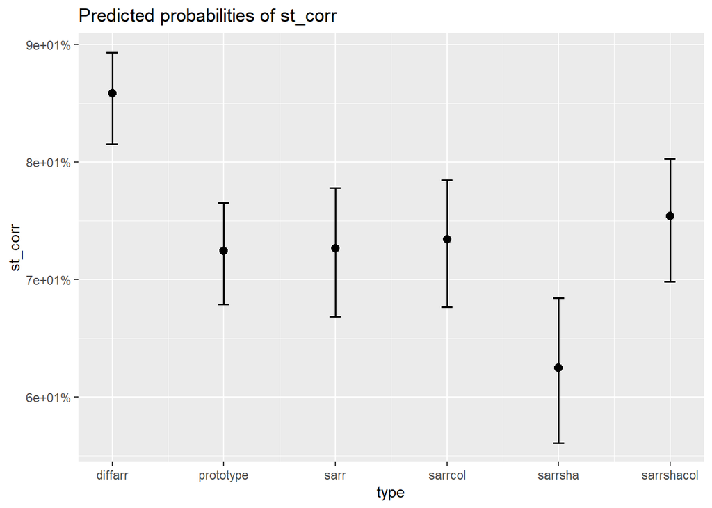

```
## Generalized linear mixed model fit by maximum likelihood (Laplace
##   Approximation) [glmerMod]
##  Family: binomial  ( logit )
## Formula: st_corr ~ DTF + (1 | workerId)
##    Data: stlmm
##
##      AIC      BIC   logLik deviance df.resid
##   3507.4   3525.5  -1750.7   3501.4     3072
##
## Scaled residuals:
##     Min      1Q  Median      3Q     Max
## -3.0542 -1.1059  0.5144  0.6380  1.3072
##
## Random effects:
##  Groups   Name        Variance Std.Dev.
##  workerId (Intercept) 0.2884   0.537
## Number of obs: 3075, groups:  workerId, 41
##
## Fixed effects:
##             Estimate Std. Error z value Pr(>|z|)
## (Intercept) 0.814009   0.099818   8.155 3.49e-16 ***
## DTF         0.048212   0.008483   5.684 1.32e-08 ***
## ---
## Signif. codes:  0 '***' 0.001 '**' 0.01 '*' 0.05 '.' 0.1 ' ' 1
##
## Correlation of Fixed Effects:
##     (Intr)
## DTF -0.332
```

```
## Package `effects` is not available, but needed for `ggeffect()`. Either install package `effects`, or use `ggpredict()`. Calling `ggpredict()` now.FALSE
```

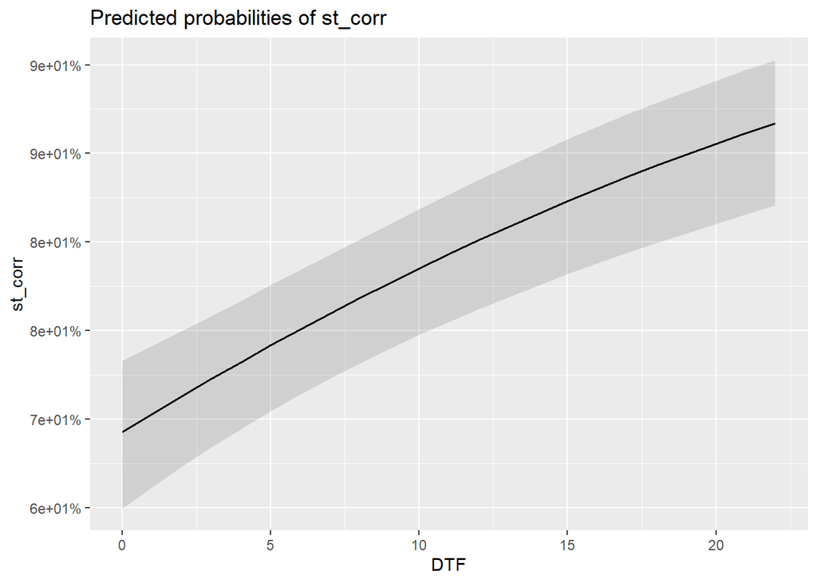

```
## Generalized linear mixed model fit by maximum likelihood (Laplace
##   Approximation) [glmerMod]
##  Family: binomial  ( logit )
## Formula: st_corr ~ DTAF + (1 | workerId)
##    Data: stlmm
##
##      AIC      BIC   logLik deviance df.resid
##   3531.3   3549.4  -1762.7   3525.3     3072
##
## Scaled residuals:
##     Min      1Q  Median      3Q     Max
## -3.1452 -1.1242  0.5137  0.6287  1.2801
##
## Random effects:
##  Groups   Name        Variance Std.Dev.
##  workerId (Intercept) 0.2834   0.5324
## Number of obs: 3075, groups:  workerId, 41
##
## Fixed effects:
##             Estimate Std. Error z value Pr(>|z|)
## (Intercept) 0.841078   0.106812   7.874 3.42e-15 ***
## DTAF        0.021060   0.006309   3.338 0.000844 ***
## ---
## Signif. codes:  0 '***' 0.001 '**' 0.01 '*' 0.05 '.' 0.1 ' ' 1
##
## Correlation of Fixed Effects:
##      (Intr)
## DTAF -0.484
```

```
## Package `effects` is not available, but needed for `ggeffect()`. Either install package `effects`, or use `ggpredict()`. Calling `ggpredict()` now.FALSE
```

```
## Data were 'prettified'. Consider using `terms="DTAF [all]"` to get smooth plots.
```

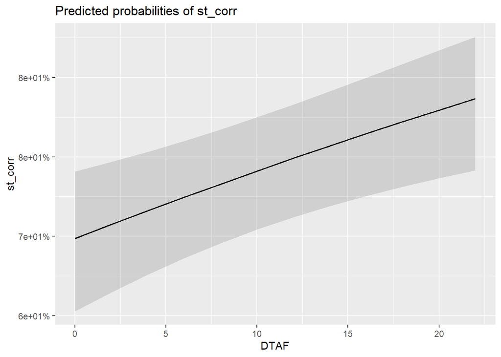

```
## Generalized linear mixed model fit by maximum likelihood (Laplace
##   Approximation) [glmerMod]
##  Family: binomial  ( logit )
## Formula: st_corr ~ DTAN + (1 | workerId)
##    Data: stlmm
##
##      AIC      BIC   logLik deviance df.resid
##   3536.1   3554.1  -1765.0   3530.1     3072
##
## Scaled residuals:
##     Min      1Q  Median      3Q     Max
## -3.1308 -1.1459  0.5139  0.6285  1.2548
##
## Random effects:
##  Groups   Name        Variance Std.Dev.
##  workerId (Intercept) 0.2824   0.5314
## Number of obs: 3075, groups:  workerId, 41
##
## Fixed effects:
##             Estimate Std. Error z value Pr(>|z|)
## (Intercept) 0.878098   0.107892   8.139    4e-16 ***
## DTAN        0.016667   0.006571   2.536   0.0112 *
## ---
## Signif. codes:  0 '***' 0.001 '**' 0.01 '*' 0.05 '.' 0.1 ' ' 1
##
## Correlation of Fixed Effects:
##      (Intr)
## DTAN -0.502
```

```
## Package `effects` is not available, but needed for `ggeffect()`. Either install package `effects`, or use `ggpredict()`. Calling `ggpredict()` now.FALSE
```

```
## Data were 'prettified'. Consider using `terms="DTAN [all]"` to get smooth plots.
```

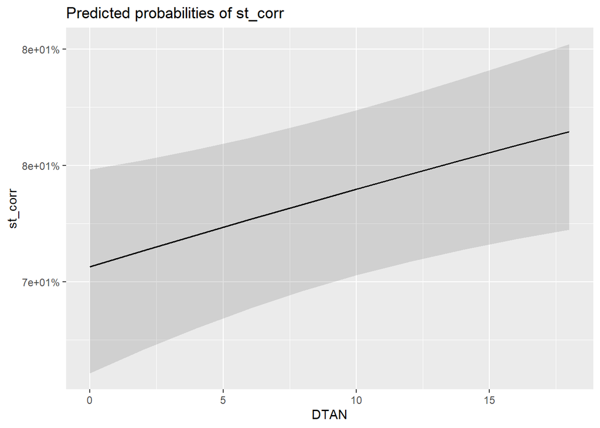

```
## Generalized linear mixed model fit by maximum likelihood (Laplace
##   Approximation) [glmerMod]
##  Family: binomial  ( logit )
## Formula: st_corr ~ DTN_byPhase + (1 | workerId)
##    Data: stlmm
##
##      AIC      BIC   logLik deviance df.resid
##   3536.1   3554.2  -1765.0   3530.1     3072
##
## Scaled residuals:
##     Min      1Q  Median      3Q     Max
## -3.1296 -1.1459  0.5136  0.6285  1.2548
##
## Random effects:
##  Groups   Name        Variance Std.Dev.
##  workerId (Intercept) 0.2824   0.5314
## Number of obs: 3075, groups:  workerId, 41
##
## Fixed effects:
##             Estimate Std. Error z value Pr(>|z|)
## (Intercept) 0.878118   0.107948   8.135 4.13e-16 ***
## DTN_byPhase 0.016096   0.006359   2.531   0.0114 *
## ---
## Signif. codes:  0 '***' 0.001 '**' 0.01 '*' 0.05 '.' 0.1 ' ' 1
##
## Correlation of Fixed Effects:
##             (Intr)
## DTN_byPhase -0.503
```

```
## Package `effects` is not available, but needed for `ggeffect()`. Either install package `effects`, or use `ggpredict()`. Calling `ggpredict()` now.FALSE
```

```
## Data were 'prettified'. Consider using `terms="DTN_byPhase [all]"` to get smooth plots.
```

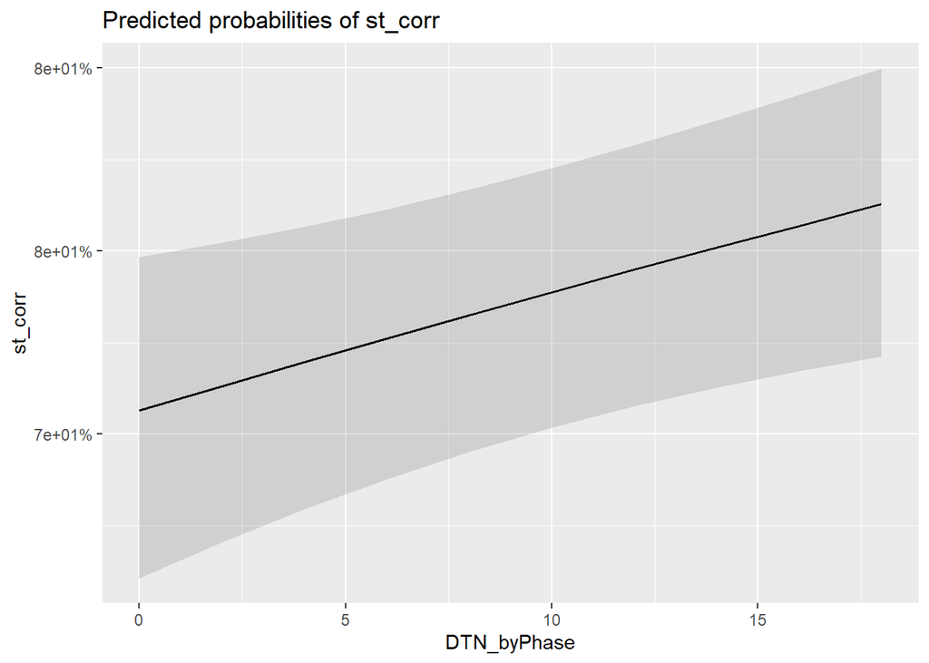

```
## Generalized linear mixed model fit by maximum likelihood (Laplace
##   Approximation) [glmerMod]
##  Family: binomial  ( logit )
## Formula: st_corr ~ DTPPm + (1 | workerId)
##    Data: stlmm
##
##      AIC      BIC   logLik deviance df.resid
##   3493.6   3511.7  -1743.8   3487.6     3072
##
## Scaled residuals:
##     Min      1Q  Median      3Q     Max
## -3.2388 -1.0829  0.5099  0.6345  1.3668
##
## Random effects:
##  Groups   Name        Variance Std.Dev.
##  workerId (Intercept) 0.2913   0.5397
## Number of obs: 3075, groups:  workerId, 41
##
## Fixed effects:
##             Estimate Std. Error z value Pr(>|z|)
## (Intercept)  -0.6638     0.2672  -2.484    0.013 *
## DTPPm         0.1348     0.0203   6.641 3.11e-11 ***
## ---
## Signif. codes:  0 '***' 0.001 '**' 0.01 '*' 0.05 '.' 0.1 ' ' 1
##
## Correlation of Fixed Effects:
##       (Intr)
## DTPPm -0.935
```

```
## Package `effects` is not available, but needed for `ggeffect()`. Either install package `effects`, or use `ggpredict()`. Calling `ggpredict()` now.FALSE
```

```
## Data were 'prettified'. Consider using `terms="DTPPm [all]"` to get smooth plots.
```

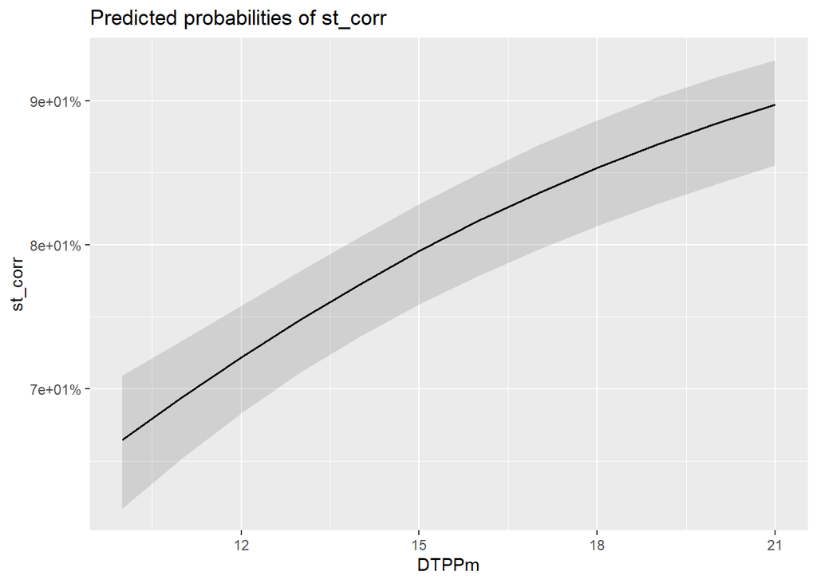

|  | st_corr |  |  |  | st_corr |  |  |  | st_corr |  |  |  | st_corr |  |  |  | st_corr |  |  |  | st_corr |  |  |  |
| --- | --- | --- | --- | --- | --- | --- | --- | --- | --- | --- | --- | --- | --- | --- | --- | --- | --- | --- | --- | --- | --- | --- | --- | --- |
| Predictors | Log-Odds | std. Error | CI | p | Log-Odds | std. Error | CI | p | Log-Odds | std. Error | CI | p | Log-Odds | std. Error | CI | p | Log-Odds | std. Error | CI | p | Log-Odds | std. Error | CI | p |
| (Intercept) | 1.80 | 0.16 | 1.48 – 2.12 | **<0.001** | 0.81 | 0.10 | 0.62 – 1.01 | **<0.001** | 0.84 | 0.11 | 0.63 – 1.05 | **<0.001** | 0.88 | 0.11 | 0.67 – 1.09 | **<0.001** | 0.88 | 0.11 | 0.67 – 1.09 | **<0.001** | -0.66 | 0.27 | -1.19 – -0.14 | **0.013** |
| type [prototype] | -0.84 | 0.16 | -1.15 – -0.53 | **<0.001** |  |  |  |  |  |  |  |  |  |  |  |  |  |  |  |  |  |  |  |  |
| type [sarr] | -0.83 | 0.18 | -1.18 – -0.48 | **<0.001** |  |  |  |  |  |  |  |  |  |  |  |  |  |  |  |  |  |  |  |  |
| type [sarrcol] | -0.79 | 0.18 | -1.14 – -0.44 | **<0.001** |  |  |  |  |  |  |  |  |  |  |  |  |  |  |  |  |  |  |  |  |
| type [sarrsha] | -1.29 | 0.17 | -1.64 – -0.95 | **<0.001** |  |  |  |  |  |  |  |  |  |  |  |  |  |  |  |  |  |  |  |  |
| type [sarrshacol] | -0.68 | 0.18 | -1.04 – -0.33 | **<0.001** |  |  |  |  |  |  |  |  |  |  |  |  |  |  |  |  |  |  |  |  |
| DTF |  |  |  |  | 0.05 | 0.01 | 0.03 – 0.06 | **<0.001** |  |  |  |  |  |  |  |  |  |  |  |  |  |  |  |  |
| DTAF |  |  |  |  |  |  |  |  | 0.02 | 0.01 | 0.01 – 0.03 | **0.001** |  |  |  |  |  |  |  |  |  |  |  |  |
| DTAN |  |  |  |  |  |  |  |  |  |  |  |  | 0.02 | 0.01 | 0.00 – 0.03 | **0.011** |  |  |  |  |  |  |  |  |
| DTN_byPhase |  |  |  |  |  |  |  |  |  |  |  |  |  |  |  |  | 0.02 | 0.01 | 0.00 – 0.03 | **0.011** |  |  |  |  |
| DTPPm |  |  |  |  |  |  |  |  |  |  |  |  |  |  |  |  |  |  |  |  | 0.13 | 0.02 | 0.10 – 0.17 | **<0.001** |
| Random Effects |  |  |  |  |  |  |  |  |  |  |  |  |  |  |  |  |  |  |  |  |  |  |  |  |
| σ<sup>2</sup> | 3.29 |  |  |  | 3.29 |  |  |  | 3.29 |  |  |  | 3.29 |  |  |  | 3.29 |  |  |  | 3.29 |  |  |  |
| τ<sub>00</sub> | 0.29 <sub>workerId</sub> |  |  |  | 0.29 <sub>workerId</sub> |  |  |  | 0.28 <sub>workerId</sub> |  |  |  | 0.28 <sub>workerId</sub> |  |  |  | 0.28 <sub>workerId</sub> |  |  |  | 0.29 <sub>workerId</sub> |  |  |  |
| ICC | 0.08 |  |  |  | 0.08 |  |  |  | 0.08 |  |  |  | 0.08 |  |  |  | 0.08 |  |  |  | 0.08 |  |  |  |
| N | 41 <sub>workerId</sub> |  |  |  | 41 <sub>workerId</sub> |  |  |  | 41 <sub>workerId</sub> |  |  |  | 41 <sub>workerId</sub> |  |  |  | 41 <sub>workerId</sub> |  |  |  | 41 <sub>workerId</sub> |  |  |  |
| Observations | 3075 |  |  |  | 3075 |  |  |  | 3075 |  |  |  | 3075 |  |  |  | 3075 |  |  |  | 3075 |  |  |  |
| Marginal R<sup>2</sup> / Conditional R<sup>2</sup> | 0.032 / 0.112 |  |  |  | 0.019 / 0.098 |  |  |  | 0.005 / 0.084 |  |  |  | 0.003 / 0.082 |  |  |  | 0.003 / 0.082 |  |  |  | 0.027 / 0.106 |  |  |  |
| AIC | 3489.320 |  |  |  | 3507.373 |  |  |  | 3531.342 |  |  |  | 3536.060 |  |  |  | 3536.087 |  |  |  | 3493.637 |  |  |  |

## Test phase

Logistic mixed regression for the test phase. Does difference from prototypes or familiarity/novelty have an effect on correct categorization in the test phase?

```
## Generalized linear mixed model fit by maximum likelihood (Laplace
##   Approximation) [glmerMod]
##  Family: binomial  ( logit )
## Formula: rt_corr ~ type * tq + (tq | workerId)
##    Data: tdlmm
##
##      AIC      BIC   logLik deviance df.resid
##   5115.8   5198.0  -2544.9   5089.8     4087
##
## Scaled residuals:
##     Min      1Q  Median      3Q     Max
## -5.4211 -0.8408  0.3134  0.8555  3.7927
##
## Random effects:
##  Groups   Name        Variance Std.Dev. Corr
##  workerId (Intercept) 0.2914   0.5398
##           tqnew       1.7846   1.3359   -0.96
## Number of obs: 4100, groups:  workerId, 41
##
## Fixed effects:
##                      Estimate Std. Error z value Pr(>|z|)
## (Intercept)           -0.8365     0.1386  -6.033 1.61e-09 ***
## typesarr               0.4088     0.1512   2.704  0.00686 **
## typesarrcol            0.6113     0.1503   4.067 4.76e-05 ***
## typesarrsha            1.2292     0.1515   8.116 4.82e-16 ***
## typesarrshacol         0.7992     0.1500   5.327 9.97e-08 ***
## tqnew                  2.5059     0.2725   9.194  < 2e-16 ***
## typesarr:tqnew        -1.2400     0.2319  -5.347 8.93e-08 ***
## typesarrcol:tqnew     -2.1587     0.2289  -9.431  < 2e-16 ***
## typesarrsha:tqnew     -2.9439     0.2298 -12.810  < 2e-16 ***
## typesarrshacol:tqnew  -2.6477     0.2292 -11.551  < 2e-16 ***
## ---
## Signif. codes:  0 '***' 0.001 '**' 0.01 '*' 0.05 '.' 0.1 ' ' 1
##
## Correlation of Fixed Effects:
##             (Intr) typesrr typsrrc typesrrsh typsrrshc tqnew  typsrr:t typsrrc:
## typesarr    -0.576
## typesarrcol -0.580  0.531
## typesarrsha -0.579  0.528   0.533
## typesrrshcl -0.582  0.533   0.537   0.535
## tqnew       -0.768  0.293   0.295   0.294     0.296
## typsrr:tqnw  0.375 -0.652  -0.346  -0.345    -0.347    -0.481
## typsrrcl:tq  0.381 -0.349  -0.657  -0.350    -0.352    -0.492  0.574
## typsrrsh:tq  0.381 -0.348  -0.351  -0.659    -0.353    -0.492  0.572    0.586
## typsrrshcl:  0.381 -0.349  -0.351  -0.350    -0.655    -0.493  0.574    0.588
##             typsrrsh:t
## typesarr
## typesarrcol
## typesarrsha
## typesrrshcl
## tqnew
## typsrr:tqnw
## typsrrcl:tq
## typsrrsh:tq
## typsrrshcl:  0.588
```

```
## Package `effects` is not available, but needed for `ggeffect()`. Either install package `effects`, or use `ggpredict()`. Calling `ggpredict()` now.FALSE
```

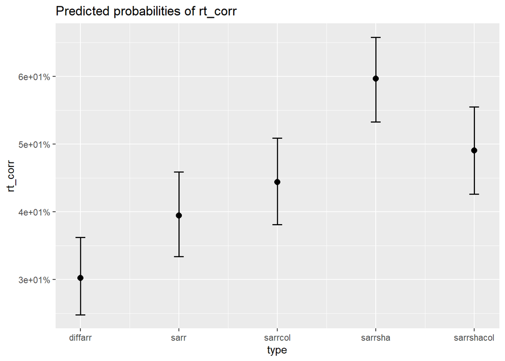

```
## Package `effects` is not available, but needed for `ggeffect()`. Either install package `effects`, or use `ggpredict()`. Calling `ggpredict()` now.FALSE
```

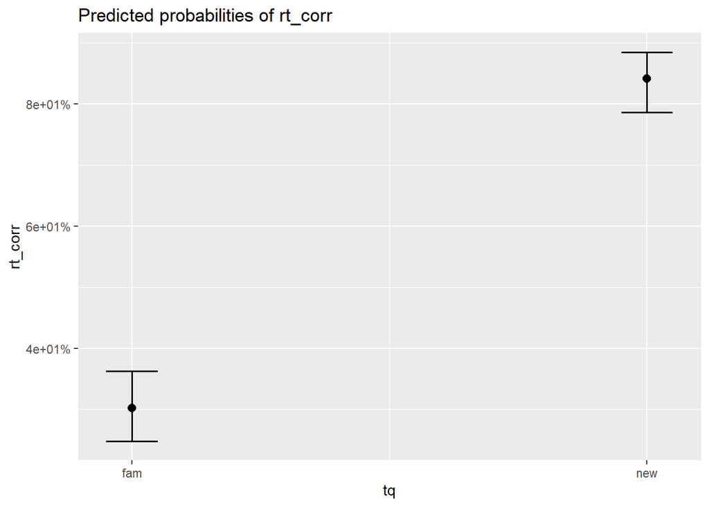

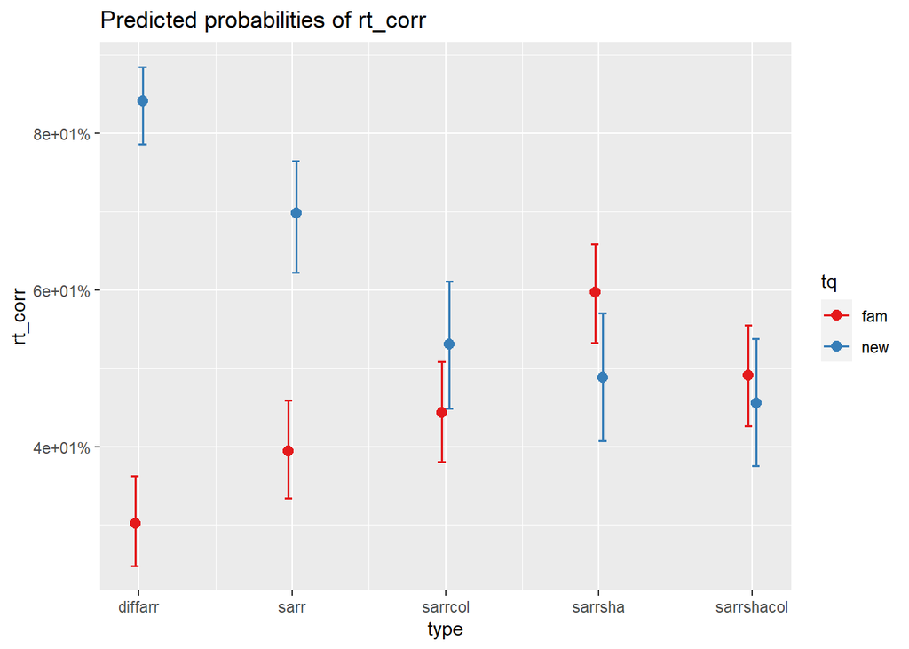

```
## Generalized linear mixed model fit by maximum likelihood (Laplace
##   Approximation) [glmerMod]
##  Family: binomial  ( logit )
## Formula: rt_corr ~ DTF * tq + (tq | workerId)
##    Data: tdlmm
##
##      AIC      BIC   logLik deviance df.resid
##   5145.3   5189.5  -2565.6   5131.3     4093
##
## Scaled residuals:
##     Min      1Q  Median      3Q     Max
## -4.4328 -0.8654  0.2960  0.8812  3.7976
##
## Random effects:
##  Groups   Name        Variance Std.Dev. Corr
##  workerId (Intercept) 0.2828   0.5318
##           tqnew       1.7490   1.3225   -0.96
## Number of obs: 4100, groups:  workerId, 41
##
## Fixed effects:
##              Estimate Std. Error z value Pr(>|z|)
## (Intercept)  0.200604   0.112052   1.790  0.07341 .
## DTF         -0.062580   0.009115  -6.866 6.61e-12 ***
## tqnew       -0.643482   0.236309  -2.723  0.00647 **
## DTF:tqnew    0.194054   0.014757  13.150  < 2e-16 ***
## ---
## Signif. codes:  0 '***' 0.001 '**' 0.01 '*' 0.05 '.' 0.1 ' ' 1
##
## Correlation of Fixed Effects:
##           (Intr) DTF    tqnew
## DTF       -0.528
## tqnew     -0.838  0.251
## DTF:tqnew  0.327 -0.618 -0.390
```

```
## Package `effects` is not available, but needed for `ggeffect()`. Either install package `effects`, or use `ggpredict()`. Calling `ggpredict()` now.FALSE
```

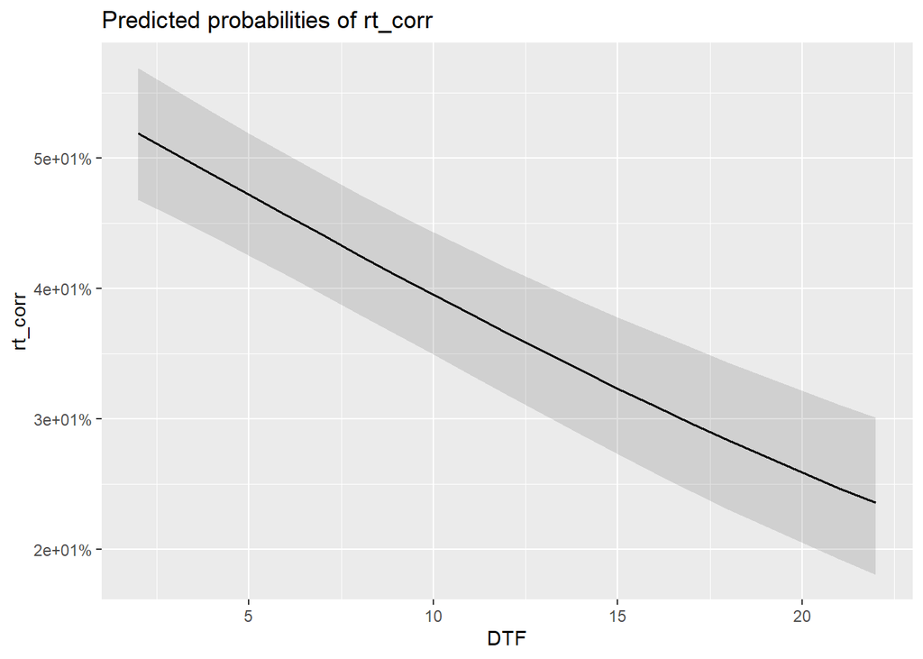

```
## Package `effects` is not available, but needed for `ggeffect()`. Either install package `effects`, or use `ggpredict()`. Calling `ggpredict()` now.FALSE
```

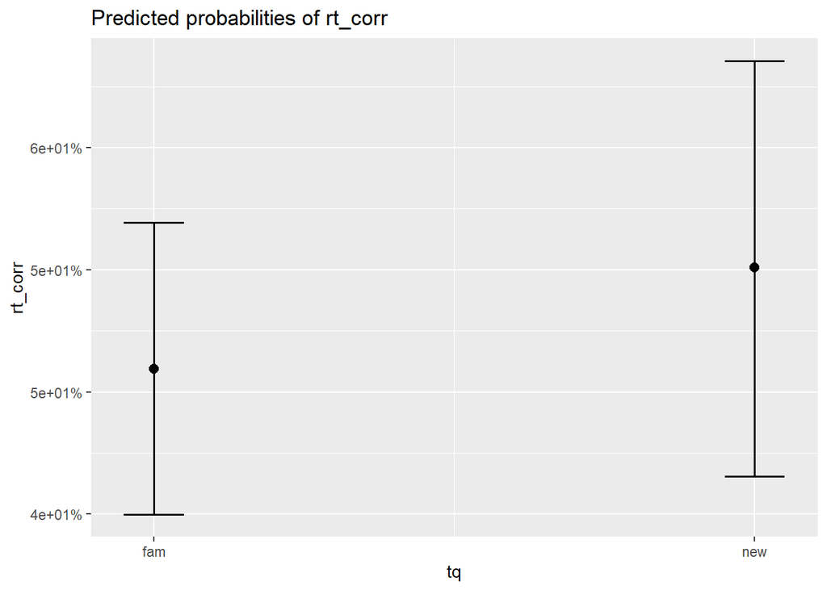

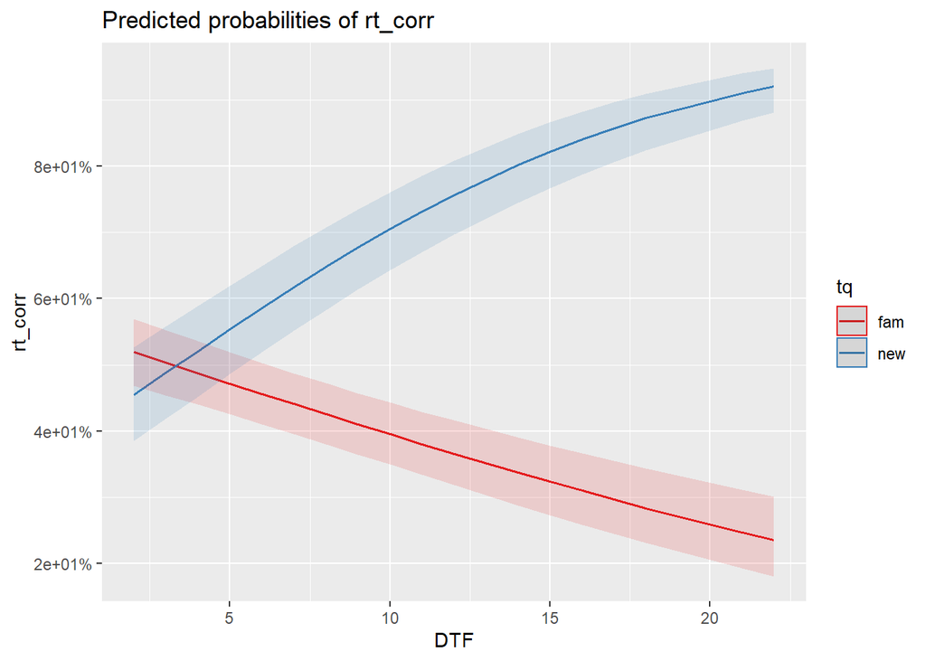

```
## Generalized linear mixed model fit by maximum likelihood (Laplace
##   Approximation) [glmerMod]
##  Family: binomial  ( logit )
## Formula: rt_corr ~ DTAF * tq + (tq | workerId)
##    Data: tdlmm
##
##      AIC      BIC   logLik deviance df.resid
##   5148.2   5192.5  -2567.1   5134.2     4093
##
## Scaled residuals:
##     Min      1Q  Median      3Q     Max
## -4.4521 -0.8694  0.3195  0.8831  3.7535
##
## Random effects:
##  Groups   Name        Variance Std.Dev. Corr
##  workerId (Intercept) 0.2863   0.5351
##           tqnew       1.7397   1.3190   -0.96
## Number of obs: 4100, groups:  workerId, 41
##
## Fixed effects:
##             Estimate Std. Error z value Pr(>|z|)
## (Intercept)  1.42243    0.23540   6.043 1.52e-09 ***
## DTAF        -0.12809    0.01694  -7.562 3.98e-14 ***
## tqnew       -3.80117    0.39381  -9.652  < 2e-16 ***
## DTAF:tqnew   0.34733    0.02608  13.320  < 2e-16 ***
## ---
## Signif. codes:  0 '***' 0.001 '**' 0.01 '*' 0.05 '.' 0.1 ' ' 1
##
## Correlation of Fixed Effects:
##            (Intr) DTAF   tqnew
## DTAF       -0.914
## tqnew      -0.702  0.546
## DTAF:tqnew  0.594 -0.650 -0.834
## convergence code: 0
## Model failed to converge with max|grad| = 0.00203705 (tol = 0.002, component 1)
```

```
## Package `effects` is not available, but needed for `ggeffect()`. Either install package `effects`, or use `ggpredict()`. Calling `ggpredict()` now.FALSE
```

```
## Data were 'prettified'. Consider using `terms="DTAF [all]"` to get smooth plots.
```

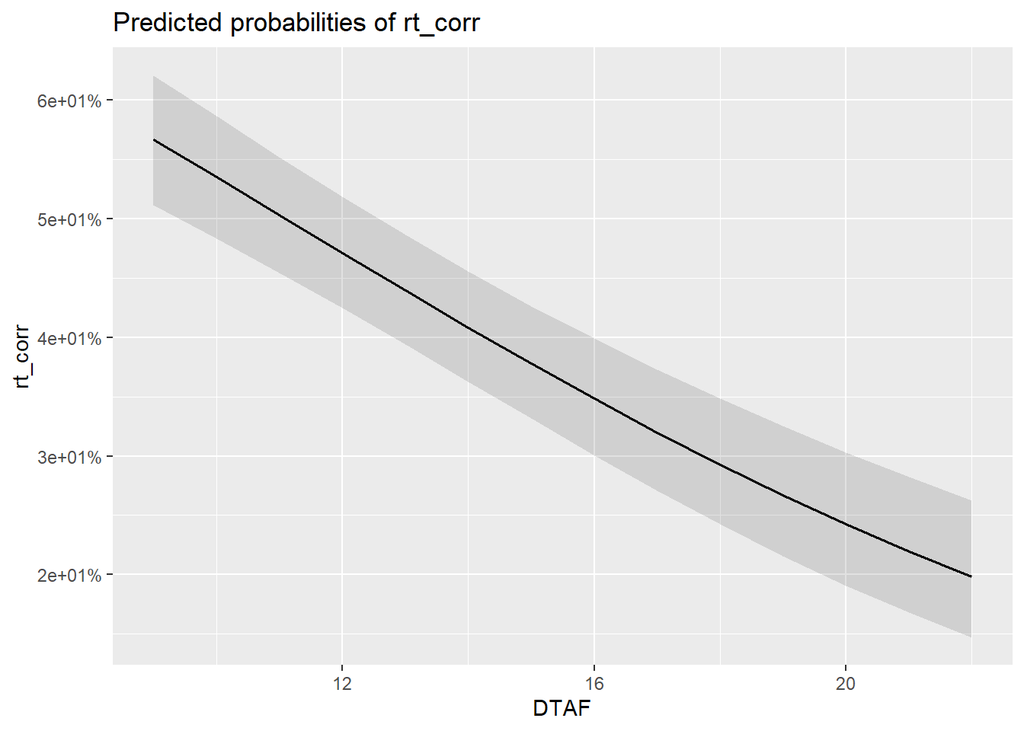

```
## Package `effects` is not available, but needed for `ggeffect()`. Either install package `effects`, or use `ggpredict()`. Calling `ggpredict()` now.FALSE
## Data were 'prettified'. Consider using `terms="DTAF [all]"` to get smooth plots.
```

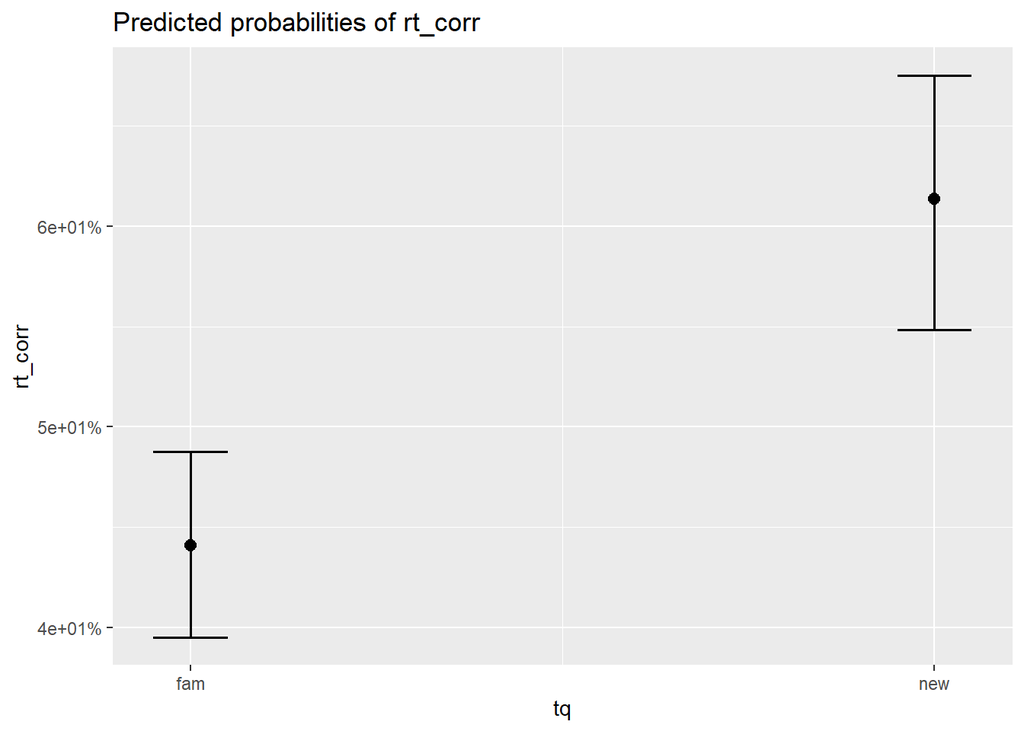

```
## Data were 'prettified'. Consider using `terms="DTAF [all]"` to get smooth plots.
```

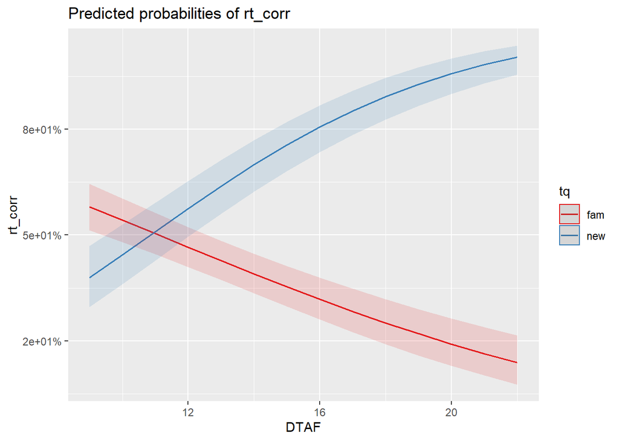

```
## Generalized linear mixed model fit by maximum likelihood (Laplace
##   Approximation) [glmerMod]
##  Family: binomial  ( logit )
## Formula: rt_corr ~ DTAN * tq + (tq | workerId)
##    Data: tdlmm
##
##      AIC      BIC   logLik deviance df.resid
##   5194.6   5238.9  -2590.3   5180.6     4093
##
## Scaled residuals:
##     Min      1Q  Median      3Q     Max
## -5.8258 -0.8706  0.3678  0.8775  4.0103
##
## Random effects:
##  Groups   Name        Variance Std.Dev. Corr
##  workerId (Intercept) 0.2815   0.5306
##           tqnew       1.6913   1.3005   -0.96
## Number of obs: 4100, groups:  workerId, 41
##
## Fixed effects:
##             Estimate Std. Error z value Pr(>|z|)
## (Intercept)  1.93609    0.33215   5.829 5.58e-09 ***
## DTAN        -0.16888    0.02504  -6.745 1.53e-11 ***
## tqnew       -5.10220    0.51912  -9.829  < 2e-16 ***
## DTAN:tqnew   0.45168    0.03740  12.076  < 2e-16 ***
## ---
## Signif. codes:  0 '***' 0.001 '**' 0.01 '*' 0.05 '.' 0.1 ' ' 1
##
## Correlation of Fixed Effects:
##            (Intr) DTAN   tqnew
## DTAN       -0.958
## tqnew      -0.694  0.613
## DTAN:tqnew  0.642 -0.670 -0.911
```

```
## Package `effects` is not available, but needed for `ggeffect()`. Either install package `effects`, or use `ggpredict()`. Calling `ggpredict()` now.FALSE
```

```
## Data were 'prettified'. Consider using `terms="DTAN [all]"` to get smooth plots.
```

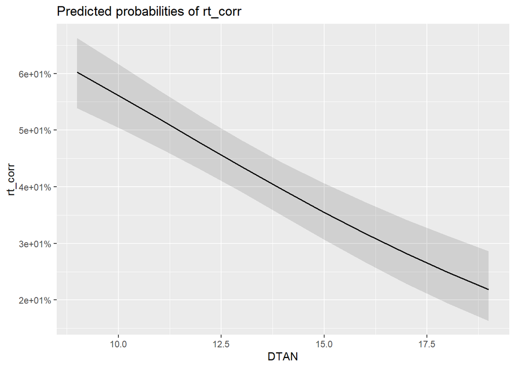

```
## Package `effects` is not available, but needed for `ggeffect()`. Either install package `effects`, or use `ggpredict()`. Calling `ggpredict()` now.FALSE
## Data were 'prettified'. Consider using `terms="DTAN [all]"` to get smooth plots.
```

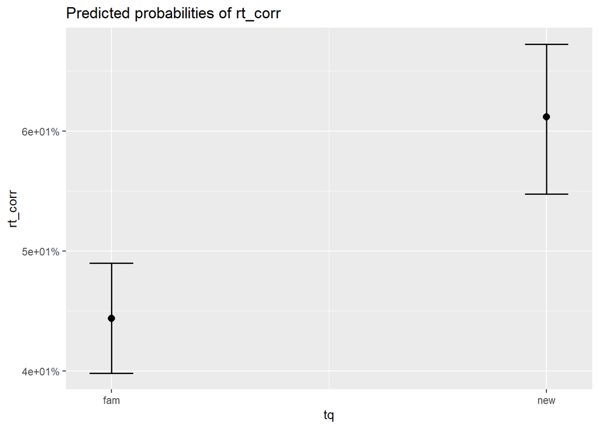

```
## Data were 'prettified'. Consider using `terms="DTAN [all]"` to get smooth plots.
```

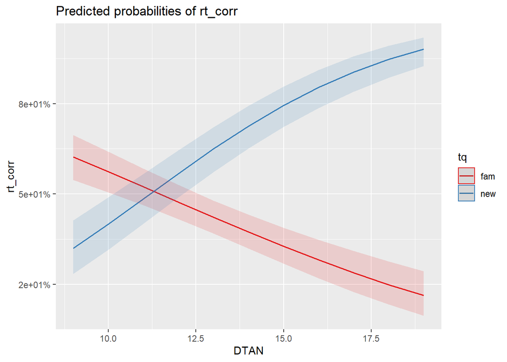

```
## Generalized linear mixed model fit by maximum likelihood (Laplace
##   Approximation) [glmerMod]
##  Family: binomial  ( logit )
## Formula: rt_corr ~ DTN_byPhase * tq + (tq | workerId)
##    Data: tdlmm
##
##      AIC      BIC   logLik deviance df.resid
##   5206.8   5251.0  -2596.4   5192.8     4093
##
## Scaled residuals:
##     Min      1Q  Median      3Q     Max
## -5.3161 -0.8726  0.3750  0.8816  3.8344
##
## Random effects:
##  Groups   Name        Variance Std.Dev. Corr
##  workerId (Intercept) 0.2804   0.5295
##           tqnew       1.6791   1.2958   -0.96
## Number of obs: 4100, groups:  workerId, 41
##
## Fixed effects:
##                   Estimate Std. Error z value Pr(>|z|)
## (Intercept)        1.92813    0.34144   5.647 1.63e-08 ***
## DTN_byPhase       -0.16247    0.02491  -6.523 6.90e-11 ***
## tqnew             -5.03484    0.52861  -9.525  < 2e-16 ***
## DTN_byPhase:tqnew  0.43054    0.03688  11.675  < 2e-16 ***
## ---
## Signif. codes:  0 '***' 0.001 '**' 0.01 '*' 0.05 '.' 0.1 ' ' 1
##
## Correlation of Fixed Effects:
##             (Intr) DTN_bP tqnew
## DTN_byPhase -0.961
## tqnew       -0.697  0.620
## DTN_byPhs:t  0.649 -0.675 -0.915
## convergence code: 0
## Model failed to converge with max|grad| = 0.00269981 (tol = 0.002, component 1)
```

```
## Package `effects` is not available, but needed for `ggeffect()`. Either install package `effects`, or use `ggpredict()`. Calling `ggpredict()` now.FALSE
```

```
## Data were 'prettified'. Consider using `terms="DTN_byPhase [all]"` to get smooth plots.
```

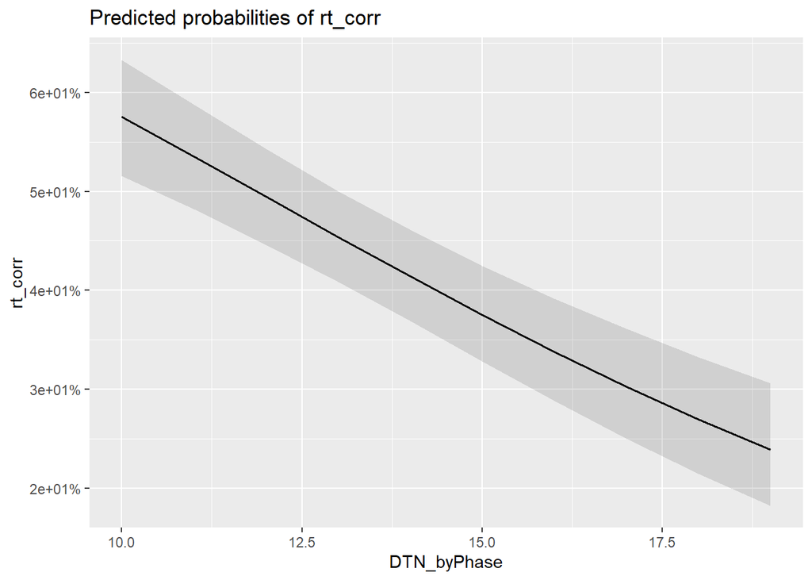

```
## Package `effects` is not available, but needed for `ggeffect()`. Either install package `effects`, or use `ggpredict()`. Calling `ggpredict()` now.FALSE
## Data were 'prettified'. Consider using `terms="DTN_byPhase [all]"` to get smooth plots.
```

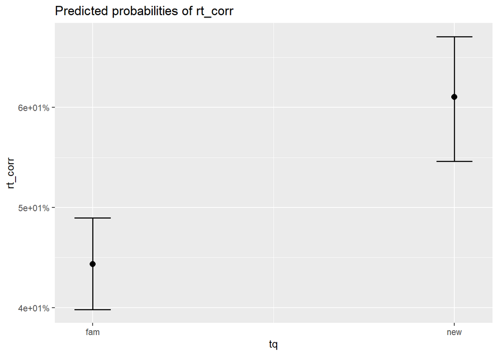

```
## Data were 'prettified'. Consider using `terms="DTN_byPhase [all]"` to get smooth plots.
```

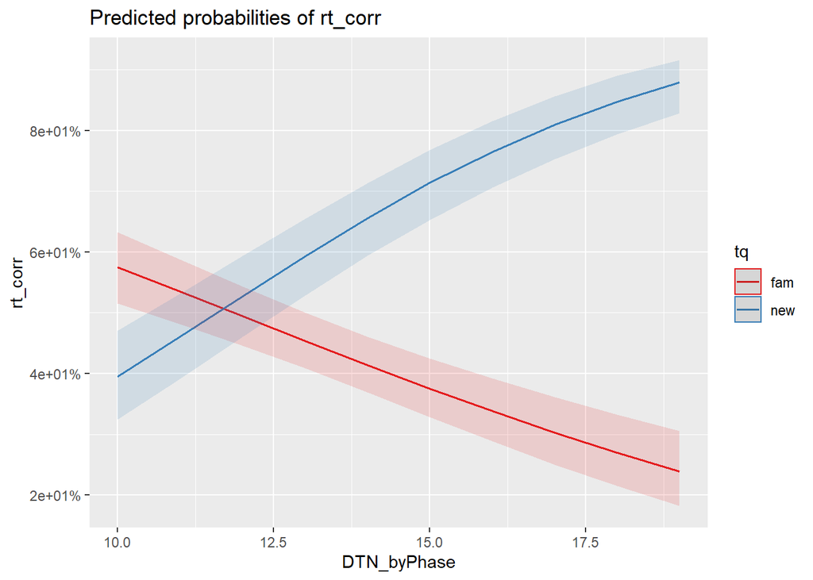

```
## Generalized linear mixed model fit by maximum likelihood (Laplace
##   Approximation) [glmerMod]
##  Family: binomial  ( logit )
## Formula: rt_corr ~ DTPPm * tq + (tq | workerId)
##    Data: tdlmm
##
##      AIC      BIC   logLik deviance df.resid
##   5140.9   5185.1  -2563.4   5126.9     4093
##
## Scaled residuals:
##     Min      1Q  Median      3Q     Max
## -4.5869 -0.8720  0.3183  0.8770  3.9062
##
## Random effects:
##  Groups   Name        Variance Std.Dev. Corr
##  workerId (Intercept) 0.2893   0.5379
##           tqnew       1.7448   1.3209   -0.96
## Number of obs: 4100, groups:  workerId, 41
##
## Fixed effects:
##             Estimate Std. Error z value Pr(>|z|)
## (Intercept)  2.22131    0.31669   7.014 2.31e-12 ***
## DTPPm       -0.17968    0.02238  -8.030 9.76e-16 ***
## tqnew       -5.67208    0.50884 -11.147  < 2e-16 ***
## DTPPm:tqnew  0.46505    0.03426  13.573  < 2e-16 ***
## ---
## Signif. codes:  0 '***' 0.001 '**' 0.01 '*' 0.05 '.' 0.1 ' ' 1
##
## Correlation of Fixed Effects:
##             (Intr) DTPPm  tqnew
## DTPPm       -0.953
## tqnew       -0.682  0.593
## DTPPm:tqnew  0.622 -0.653 -0.904
```

```
## Package `effects` is not available, but needed for `ggeffect()`. Either install package `effects`, or use `ggpredict()`. Calling `ggpredict()` now.FALSE
```

```
## Data were 'prettified'. Consider using `terms="DTPPm [all]"` to get smooth plots.
```

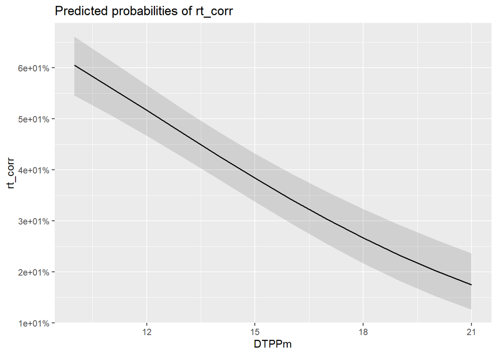

```
## Package `effects` is not available, but needed for `ggeffect()`. Either install package `effects`, or use `ggpredict()`. Calling `ggpredict()` now.FALSE
## Data were 'prettified'. Consider using `terms="DTPPm [all]"` to get smooth plots.
```

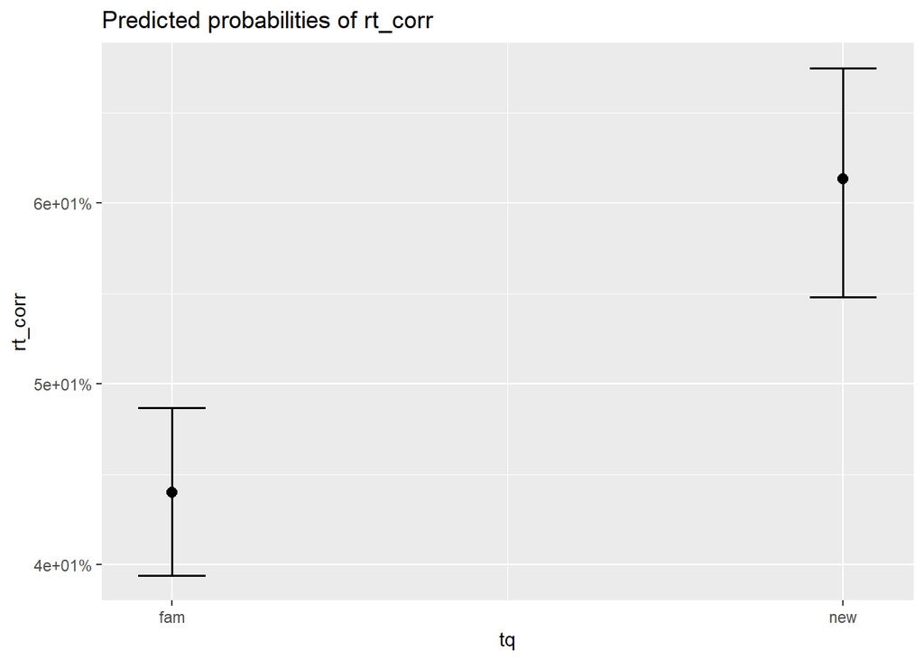

```
## Data were 'prettified'. Consider using `terms="DTPPm [all]"` to get smooth plots.
```

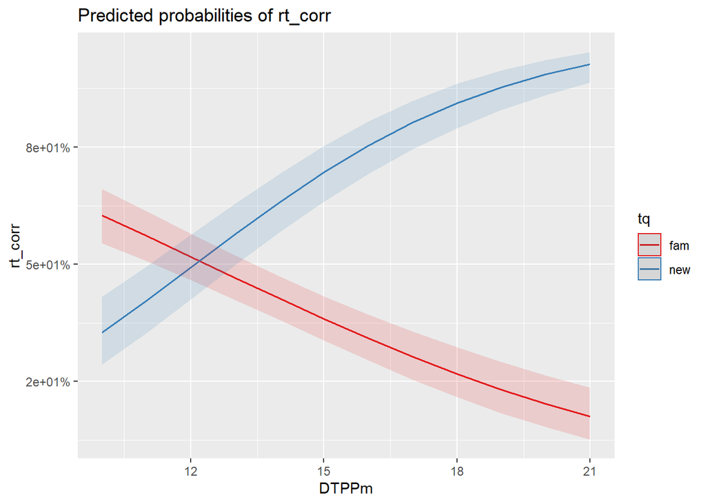

|  | rt_corr |  |  |  | rt_corr |  |  |  | rt_corr |  |  |  | rt_corr |  |  |  | rt_corr |  |  |  | rt_corr |  |  |  |
| --- | --- | --- | --- | --- | --- | --- | --- | --- | --- | --- | --- | --- | --- | --- | --- | --- | --- | --- | --- | --- | --- | --- | --- | --- |
| Predictors | Log-Odds | std. Error | CI | p | Log-Odds | std. Error | CI | p | Log-Odds | std. Error | CI | p | Log-Odds | std. Error | CI | p | Log-Odds | std. Error | CI | p | Log-Odds | std. Error | CI | p |
| (Intercept) | -0.84 | 0.14 | -1.11 – -0.56 | **<0.001** | 0.20 | 0.11 | -0.02 – 0.42 | 0.073 | 1.42 | 0.24 | 0.96 – 1.88 | **<0.001** | 1.94 | 0.33 | 1.29 – 2.59 | **<0.001** | 1.93 | 0.34 | 1.26 – 2.60 | **<0.001** | 2.22 | 0.32 | 1.60 – 2.84 | **<0.001** |
| type [sarr] | 0.41 | 0.15 | 0.11 – 0.71 | **0.007** |  |  |  |  |  |  |  |  |  |  |  |  |  |  |  |  |  |  |  |  |
| type [sarrcol] | 0.61 | 0.15 | 0.32 – 0.91 | **<0.001** |  |  |  |  |  |  |  |  |  |  |  |  |  |  |  |  |  |  |  |  |
| type [sarrsha] | 1.23 | 0.15 | 0.93 – 1.53 | **<0.001** |  |  |  |  |  |  |  |  |  |  |  |  |  |  |  |  |  |  |  |  |
| type [sarrshacol] | 0.80 | 0.15 | 0.51 – 1.09 | **<0.001** |  |  |  |  |  |  |  |  |  |  |  |  |  |  |  |  |  |  |  |  |
| tq [new] | 2.51 | 0.27 | 1.97 – 3.04 | **<0.001** | -0.64 | 0.24 | -1.11 – -0.18 | **0.006** | -3.80 | 0.39 | -4.57 – -3.03 | **<0.001** | -5.10 | 0.52 | -6.12 – -4.08 | **<0.001** | -5.03 | 0.53 | -6.07 – -4.00 | **<0.001** | -5.67 | 0.51 | -6.67 – -4.67 | **<0.001** |
| type [sarr] * tq [new] | -1.24 | 0.23 | -1.69 – -0.79 | **<0.001** |  |  |  |  |  |  |  |  |  |  |  |  |  |  |  |  |  |  |  |  |
| type [sarrcol] * tq [new] | -2.16 | 0.23 | -2.61 – -1.71 | **<0.001** |  |  |  |  |  |  |  |  |  |  |  |  |  |  |  |  |  |  |  |  |
| type [sarrsha] * tq [new] | -2.94 | 0.23 | -3.39 – -2.49 | **<0.001** |  |  |  |  |  |  |  |  |  |  |  |  |  |  |  |  |  |  |  |  |
| type [sarrshacol] * tq [new] | -2.65 | 0.23 | -3.10 – -2.20 | **<0.001** |  |  |  |  |  |  |  |  |  |  |  |  |  |  |  |  |  |  |  |  |
| DTF |  |  |  |  | -0.06 | 0.01 | -0.08 – -0.04 | **<0.001** |  |  |  |  |  |  |  |  |  |  |  |  |  |  |  |  |
| DTF * tq [new] |  |  |  |  | 0.19 | 0.01 | 0.17 – 0.22 | **<0.001** |  |  |  |  |  |  |  |  |  |  |  |  |  |  |  |  |
| DTAF |  |  |  |  |  |  |  |  | -0.13 | 0.02 | -0.16 – -0.09 | **<0.001** |  |  |  |  |  |  |  |  |  |  |  |  |
| DTAF * tq [new] |  |  |  |  |  |  |  |  | 0.35 | 0.03 | 0.30 – 0.40 | **<0.001** |  |  |  |  |  |  |  |  |  |  |  |  |
| DTAN |  |  |  |  |  |  |  |  |  |  |  |  | -0.17 | 0.03 | -0.22 – -0.12 | **<0.001** |  |  |  |  |  |  |  |  |
| DTAN * tq [new] |  |  |  |  |  |  |  |  |  |  |  |  | 0.45 | 0.04 | 0.38 – 0.52 | **<0.001** |  |  |  |  |  |  |  |  |
| DTN_byPhase |  |  |  |  |  |  |  |  |  |  |  |  |  |  |  |  | -0.16 | 0.02 | -0.21 – -0.11 | **<0.001** |  |  |  |  |
| DTN_byPhase * tq [new] |  |  |  |  |  |  |  |  |  |  |  |  |  |  |  |  | 0.43 | 0.04 | 0.36 – 0.50 | **<0.001** |  |  |  |  |
| DTPPm |  |  |  |  |  |  |  |  |  |  |  |  |  |  |  |  |  |  |  |  | -0.18 | 0.02 | -0.22 – -0.14 | **<0.001** |
| DTPPm * tq [new] |  |  |  |  |  |  |  |  |  |  |  |  |  |  |  |  |  |  |  |  | 0.47 | 0.03 | 0.40 – 0.53 | **<0.001** |
| Random Effects |  |  |  |  |  |  |  |  |  |  |  |  |  |  |  |  |  |  |  |  |  |  |  |  |
| σ<sup>2</sup> | 3.29 |  |  |  | 3.29 |  |  |  | 3.29 |  |  |  | 3.29 |  |  |  | 3.29 |  |  |  | 3.29 |  |  |  |
| τ<sub>00</sub> | 0.29 <sub>workerId</sub> |  |  |  | 0.28 <sub>workerId</sub> |  |  |  | 0.29 <sub>workerId</sub> |  |  |  | 0.28 <sub>workerId</sub> |  |  |  | 0.28 <sub>workerId</sub> |  |  |  | 0.29 <sub>workerId</sub> |  |  |  |
| τ<sub>11</sub> | 1.78 <sub>workerId.tqnew</sub> |  |  |  | 1.75 <sub>workerId.tqnew</sub> |  |  |  | 1.74 <sub>workerId.tqnew</sub> |  |  |  | 1.69 <sub>workerId.tqnew</sub> |  |  |  | 1.68 <sub>workerId.tqnew</sub> |  |  |  | 1.74 <sub>workerId.tqnew</sub> |  |  |  |
| ρ<sub>01</sub> | -0.96 <sub>workerId</sub> |  |  |  | -0.96 <sub>workerId</sub> |  |  |  | -0.96 <sub>workerId</sub> |  |  |  | -0.96 <sub>workerId</sub> |  |  |  | -0.96 <sub>workerId</sub> |  |  |  | -0.96 <sub>workerId</sub> |  |  |  |
| ICC | 0.13 |  |  |  | 0.13 |  |  |  | 0.13 |  |  |  | 0.12 |  |  |  | 0.12 |  |  |  | 0.13 |  |  |  |
| N | 41 <sub>workerId</sub> |  |  |  | 41 <sub>workerId</sub> |  |  |  | 41 <sub>workerId</sub> |  |  |  | 41 <sub>workerId</sub> |  |  |  | 41 <sub>workerId</sub> |  |  |  | 41 <sub>workerId</sub> |  |  |  |
| Observations | 4100 |  |  |  | 4100 |  |  |  | 4100 |  |  |  | 4100 |  |  |  | 4100 |  |  |  | 4100 |  |  |  |
| Marginal R<sup>2</sup> / Conditional R<sup>2</sup> | 0.106 / 0.222 |  |  |  | 0.102 / 0.216 |  |  |  | 0.097 / 0.212 |  |  |  | 0.078 / 0.191 |  |  |  | 0.073 / 0.187 |  |  |  | 0.099 / 0.214 |  |  |  |
| AIC | 5115.928 |  |  |  | 5145.318 |  |  |  | 5148.264 |  |  |  | 5194.652 |  |  |  | 5206.816 |  |  |  | 5140.892 |  |  |  |

The difference in correct recognitions and correct rejections between categories is due to the fact that they are more or less similar to the prototypes (thus this may be the effect of the familiarization phase which we also saw in the study phase).

During the task the participants generate predictions as to what happens next (not due to the instructions but automatically). Those stimuli that are most different from most of the stimuli should be remembered better.

By calculating a the number of correct recognitions (old - seen) and correct rejections (new - not seen) and correcting these numbers with the respective false alarm rates (new - seen; old - not seen) and adding these we get a number that reflects how well the participants distinguished pictures in the test phase. These numbers are very low (below 5 which translates to a rating of about 0.25 - the corrected rate of correct categorizations - max would be 20 for a category), which suggests that the task was hard. Yet there are differences in this number between the categories which shows that some categories were more likely to be correctly categorized. We would expect that diffarf would be the highest, while sharrshacol the lowest, with a gradual decrease through the other categories. This is partly supported by the data, but the experiment should be repeated with an easier stimulus set.